# Exercise 1

- Ladislaus Josephovich Bortkiewicz was a Russian economist and statistician. He noted that the Poisson distribution can be very useful in applied statistics when describing low-frequency events in a large population. In a famous example he showed that the number of deaths by horse kick among the Prussian army follows the Poisson distribution.
- Considering the following two sets of observations taken over a fixed large time interval in two different corps:

| $y$ death soldiers | 0 | 1 | 2 | 3 | 4 | $\geq$ 5 |
| --- | --- | --- | --- | --- | --- | --- |
| $n_1$ observations | 109 | 65 | 22 | 3 | 1 | 0 |
| $n_2$ observations | 144 | 91 | 32 | 11 | 2 | 0 |

#### 1. assuming a uniform prior, compute and plot the posterior distribution for $\lambda$, the death rate over the measurement time. Determine the posterior mean, median and variance, and compute the 95 % credibility interval.

```r
# plot layout
options(repr.plot.width = 15, repr.plot.height = 8)
```

```r
y1 <- c(rep(0,109), rep(1,65), rep(2,22), rep(3,3), rep(4,1))
y2 <- c(rep(0,144), rep(1,91), rep(2,32), rep(3,11), rep(4,2))
```

```r
n <- 1000
lambda <- seq(0.1, 1.1, 1/n)
```

##### Useful functions

```r
# function to find the mean of the distributions
find_mean <- function(lambda, alpha, mu){
    mean <- integrate(function(lambda) dgamma(lambda, alpha, mu) * lambda, 0.1, 1.1)
    return(mean)
}
```

```r
# function to find the cdf
find_cum <- function(f){
    cum <- rep(0, length(f))
    for(i in 2:length(f)){
     cum[i] <- cum[i-1] + f[i]/n
    }
    return(cum)
}
```

```r
# function to find the median
find_median <- function(f, cumn){
    for(i in 1:length(f)){
        if(cumn[i] > 0.5){
            break()
        }
    }
    return(lambda[i])
}
```

```r
# function to find the variance
find_var <- function(alpha, mean, mu){
    E2 <- integrate(function(lambda) dgamma(lambda, alpha, mu) * lambda^2, 0.1, 1.1)
    var <- E2$value - mean$value^2
    return(var)
}
```

```r
# function to find the credibility interval
find_interval <- function(cumn, percentage){
    for(i in 1: length(cumn)){
        if(cumn[i] > percentage){
            break
        }
    }
    return(lambda[i])
}
```

Assuming the measurements as independent, the likelihood for each of the two observations becomes $$ f(\{y_i\}|\lambda) = \prod_{i=1}^{n_{obs}} f(y_i|\lambda) \propto \lambda^{\sum_{i=1}^{n_{obs}} y_i} e^{-n_{obs}\lambda} $$ This is proportional to a Gamma distribution $Gamma(\lambda|\alpha, \mu)$ with $$ \alpha = \sum_{i=1}^{n_{obs}} y_i + 1 \qquad \text{and} \qquad \mu = n_{obs} $$

```r
mu1 <- length(y1)
mu2 <- length(y2)

# compute the likelihood for the first observation
alpha1 <- sum(y1) + 1
likel1 <- dgamma(lambda, alpha1, mu1)

# compute the likelihood fo the second observation
alpha2 <- sum(y2) +1
likel2 <- dgamma(lambda, alpha2, mu2)
```

```r
# normalized posteriors
post1 <- likel1
post2 <- likel2
```

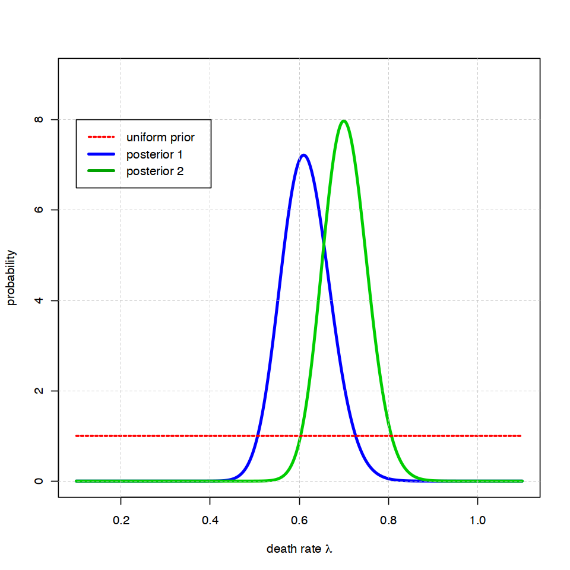

```r
# plot the posteriors
options(repr.plot.width = 8, repr.plot.height = 8)
plot(lambda, post1,
    type = 'l', lwd = 3,
    col = 'blue',
    xlab = expression(paste("death rate ", lambda)), ylab = 'probability',
    ylim = c(0, 9))
lines(lambda, post2,
    type = 'l', lwd = 3,
    col = 'green3')
lines(lambda, rep(1, length(lambda)),
    type = 'l', lwd = 2, lty = 2,
    col = 'red')
grid(nx = NULL, ny = NULL,
	lty = 2, lwd = 0.5,
	col = 'gray')
legend(0.1, 8,
	legend = c('uniform prior', 'posterior 1', 'posterior 2'),
	col = c('red', 'blue', '#00a200'),
	lty = c(2, 1, 1), lwd = c(2, 3, 3), cex = 1)
```

```r
# means of the two posterior distributions
mean1 <- find_mean(lambda, alpha1, mu1)
mean2 <- find_mean(lambda, alpha2, mu2)

cat(paste("The means of the two posteriors are: mean_1 =", round(mean1$value,3), "and mean_2 =", round(mean2$value,3)))
```

```
The means of the two posteriors are: mean_1 = 0.615 and mean_2 = 0.704
```

```r
# cumulatives of the two distributions
cum1 <- find_cum(post1)
cum2 <- find_cum(post2)
```

```r
# medians of the two posterior distributions
median1 <- find_median(post1, cum1)
median2 <- find_median(post2, cum2)

cat(paste("The medians of the two posteriors are: median_1 =", round(median1, 3), "and median_2 =", round(median2, 3)))
```

```
The medians of the two posteriors are: median_1 = 0.613 and median_2 = 0.702
```

```r
# variances of the two posterior distributions
var1 <- find_var(alpha1, mean1, mu1)
var2 <- find_var(alpha2, mean2, mu2)

cat(paste("The variances of the two posteriors are: var_1 =", round(var1, 5), "and var_2 =", round(var2, 5)))
```

```
The variances of the two posteriors are: var_1 = 0.00308 and var_2 = 0.00251
```

```r
# 95% credibility intervals of the two posterior distributions
min1 <- find_interval(cum1, 0.025)
max1 <- find_interval(cum1, 0.975)

min2 <- find_interval(cum2, 0.025)
max2 <- find_interval(cum2, 0.975)

cat(paste("The two credibility intervals are: ", round(min1, 3), "-", round(max1, 3), ", and ", round(min2, 3), "-", round(max2, 3)))
```

```
The two credibility intervals are:  0.511 - 0.728 , and  0.609 - 0.805
```

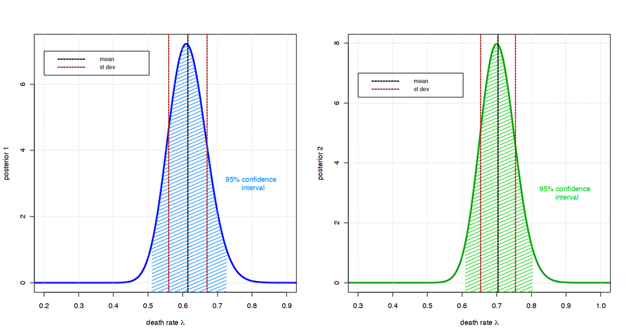

```r
par(mfrow=c(1,2), oma = c(0, 0, 0, 0))

# plot posterior 1
plot(lambda, post1,
    type = 'l', lwd = 3,
    col = 'blue',
    xlab = expression(paste("death rate ", lambda)), ylab = 'posterior 1',
	xlim = c(0.2, 0.9))
polygon(c(lambda[lambda >= min1 & lambda <= max1],
		min1),
	c(post1[lambda >= min1 & lambda <= max1],
		-100),
    col = "#0080ff", density = 20, angle = 45,
    border = 0.5,
    text(x = 0.8, y = 3, paste("95% confidence \n interval"), col = "#0080ff"))
abline(v = mean1$value,
	lty = 2, lwd = 2,
    col = 'black')
abline(v = mean1$value + sqrt(var1),
	lty = 2, lwd = 2,
	col = 'firebrick')
abline(v = mean1$value - sqrt(var1),
	lty = 2, lwd = 2,
	col = 'firebrick')
grid(nx = NULL, ny = NULL,
	lty = 2, lwd = 0.5,
	col = 'gray')
legend(0.2, 7,
	legend = c('mean', 'st dev'),
	col = c('black', 'firebrick'),
	lty = 2, lwd = 2, cex = .8)

# plot posterior 2
plot(lambda, post2,
    type = 'l', lwd = 3,
    col = '#00a200',
    xlab = expression(paste("death rate ", lambda)), ylab = 'posterior 2',
	xlim = c(0.3, 1))
polygon(c(lambda[lambda >= min2 & lambda <= max2],
		min2),
	c(post2[lambda >= min2 & lambda <= max2],
		-100),
    col = "green3", density = 20, angle = 45,
    border = 0.5,
    text(x = 0.9, y = 3, paste("95% confidence \n interval"), col = "green3"))
abline(v = mean2$value,
	lty = 2, lwd = 2,
    col = 'black')
abline(v = mean2$value + sqrt(var2),
	lty = 2, lwd = 2,
	col = 'firebrick')
abline(v = mean2$value - sqrt(var2),
	lty = 2, lwd = 2,
	col = 'firebrick')
grid(nx = NULL, ny = NULL,
	lty = 2, lwd = 0.5,
	col = 'gray')
legend(0.3, 7,
	legend = c('mean', 'st dev'),
	col = c('black', 'firebrick'),
	lty = 2, lwd = 2, cex = .8)
```

#### Summary table

| Observation | Mean | Median | Variance | 95% cred. int. |
| --- | --- | --- | --- | --- |
| n1 | 0.615 | 0.613 | 3.08 $\cdot 10^{-3}$ | 0.511 - 0.728 |
| n2 | 0.704 | 0.702 | 2.51 $\cdot 10^{-3}$ | 0.609 - 0.805 |

#### 2. assuming now a Jeffreys’ prior, $$ g(\lambda) \propto \frac{1}{\sqrt{\lambda}} \qquad \text{, with} \quad \lambda > 0 $$ compute and plot the posterior distribution for $\lambda$, the death rate over the measurement time. Determine the posterior mean, median and variance, and compute the 95% credibility interval.

Assuming now a Jeffrey's prior, the posterior is $$ P(\lambda|\{y_i\}) \propto f(\{y_i\}|\lambda) \times g(\lambda)$$ This is proportional to a Gamma distribution $Gamma(\lambda|\beta, \mu)$ with $$ \beta = \sum_{i=1}^{n_{obs}} y_i + \frac{1}{2} \qquad \text{and} \qquad \mu = n_{obs} $$

```r
beta1 <- sum(y1) + 1./2.
beta2 <- sum(y2) + 1./2.
```

```r
prior_jeff <- function(lambda){
    g <- 1/sqrt(lambda)
    return(g)
}
```

```r
# compute the posteriors
post1_jeff <- dgamma(lambda, beta1, mu1)
post2_jeff <- dgamma(lambda, beta2, mu2)
```

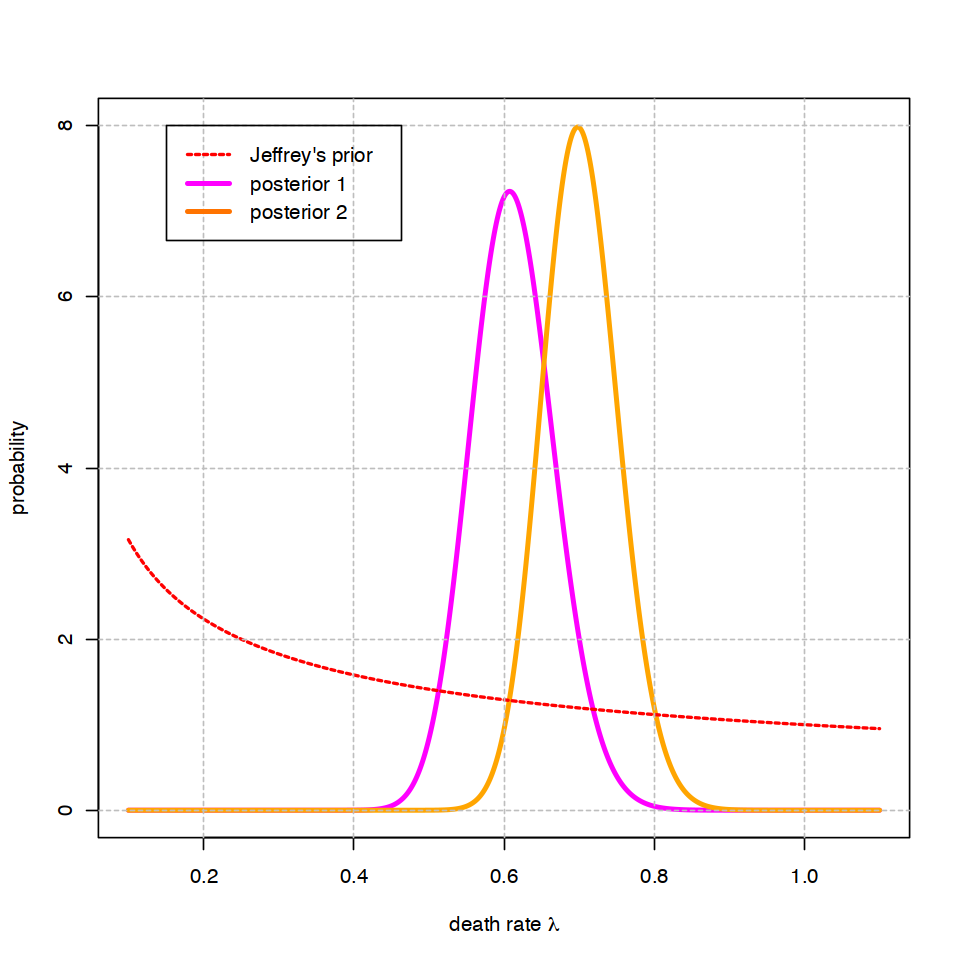

```r
# plot the posteriors
options(repr.plot.width = 8, repr.plot.height = 8)
plot(lambda, post1_jeff,
    type = 'l', lwd = 3,
    col = 'magenta',
    xlab = expression(paste("death rate ", lambda)), ylab = 'probability',
    ylim = c(0, 8))
lines(lambda, post2_jeff,
    type = 'l', lwd = 3,
    col = 'orange')
lines(lambda, prior_jeff(lambda),
    type = 'l', lwd = 2, lty = 2,
    col = 'red')
grid(nx = NULL, ny = NULL,
	lty = 2, lwd = ,
	col = 'gray')
legend(0.15, 8,
	legend = c("Jeffrey's prior", 'posterior 1', 'posterior 2'),
	col = c('red', 'magenta', '#ff7300'),
	lty = c(2, 1, 1), lwd = c(2, 3, 3), cex = 1)
```

```r
# means of the two posterior distributions
mean1_jeff <- find_mean(lambda, beta1, mu1)
mean2_jeff <- find_mean(lambda, beta2, mu2)

cat(paste("The means of the two posteriors are: mean_1 =", round(mean1_jeff$value,3), "and mean_2 =", round(mean2_jeff$value,3)))
```

```
The means of the two posteriors are: mean_1 = 0.612 and mean_2 = 0.702
```

```r
# cumulatives of the two distributions
cum1_jeff <- find_cum(post1_jeff)
cum2_jeff <- find_cum(post2_jeff)
```

```r
# medians of the two posterior distributions
median1_jeff <- find_median(post1_jeff, cum1_jeff)
median2_jeff <- find_median(post2_jeff, cum2_jeff)

cat(paste("The medians of the two posteriors are: median_1 =", round(median1_jeff, 3), "and median_2 =", round(median2_jeff, 3)))
```

```
The medians of the two posteriors are: median_1 = 0.611 and median_2 = 0.701
```

```r
# variances of the two posterior distributions
var1_jeff <- find_var(beta1, mean1_jeff, mu1)
var2_jeff <- find_var(beta2, mean2_jeff, mu2)

cat(paste("The variances of the two posteriors are: var_1 =", round(var1_jeff, 5), "and var_2 =", round(var2_jeff, 5)))
```

```
The variances of the two posteriors are: var_1 = 0.00306 and var_2 = 0.00251
```

```r
# 95% credibility intervals of the two posterior distributions
min1_jeff <- find_interval(cum1_jeff, 0.025)
max1_jeff <- find_interval(cum1_jeff, 0.975)

min2_jeff <- find_interval(cum2_jeff, 0.025)
max2_jeff <- find_interval(cum2_jeff, 0.975)

cat(paste("The two credibility intervals are: ", round(min1_jeff, 3), "-", round(max1_jeff, 3), ", and ", round(min2_jeff, 3), "-", round(max2_jeff, 3)))
```

```
The two credibility intervals are:  0.509 - 0.726 , and  0.607 - 0.803
```

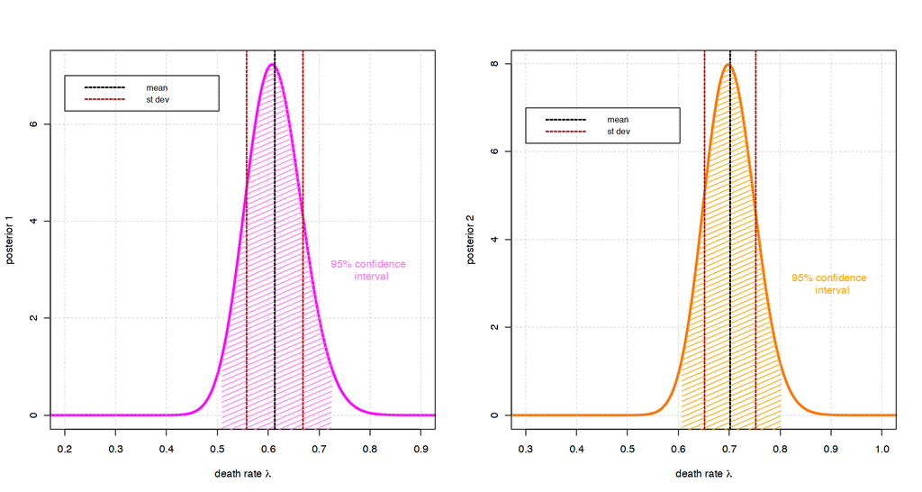

```r
par(mfrow=c(1,2), oma = c(0, 0, 0, 0))

# plot posterior 1
plot(lambda, post1_jeff,
    type = 'l', lwd = 3,
    col = 'magenta',
    xlab = expression(paste("death rate ", lambda)), ylab = 'posterior 1',
	xlim = c(0.2, 0.9))
polygon(c(lambda[lambda >= min1_jeff & lambda <= max1_jeff],
		min1_jeff),
	c(post1[lambda >= min1_jeff & lambda <= max1_jeff],
		-100),
    col = "#ff72f3", density = 20, angle = 45,
    border = 0.5,
    text(x = 0.8, y = 3, paste("95% confidence \n interval"), col = "#ff72f3"))
abline(v = mean1_jeff$value,
	lty = 2, lwd = 2,
    col = 'black')
abline(v = mean1_jeff$value + sqrt(var1_jeff),
	lty = 2, lwd = 2,
	col = 'firebrick')
abline(v = mean1_jeff$value - sqrt(var1_jeff),
	lty = 2, lwd = 2,
	col = 'firebrick')
grid(nx = NULL, ny = NULL,
	lty = 2, lwd = 0.5,
	col = 'gray')
legend(0.2, 7,
	legend = c('mean', 'st dev'),
	col = c('black', 'firebrick'),
	lty = 2, lwd = 2, cex = .8)

# plot posterior 2
plot(lambda, post2_jeff,
    type = 'l', lwd = 3,
    col = "#ff7300",
    xlab = expression(paste("death rate ", lambda)), ylab = 'posterior 2',
	xlim = c(0.3, 1))
polygon(c(lambda[lambda >= min2_jeff & lambda <= max2_jeff],
		min2_jeff),
	c(post2[lambda >= min2_jeff & lambda <= max2_jeff],
		-100),
    col = "orange", density = 20, angle = 45,
    border = 0.5,
    text(x = 0.9, y = 3, paste("95% confidence \n interval"), col = 'orange'))
abline(v = mean2_jeff$value,
	lty = 2, lwd = 2,
    col = 'black')
abline(v = mean2_jeff$value + sqrt(var2_jeff),
	lty = 2, lwd = 2,
	col = 'firebrick')
abline(v = mean2_jeff$value - sqrt(var2_jeff),
	lty = 2, lwd = 2,
	col = 'firebrick')
grid(nx = NULL, ny = NULL,
	lty = 2, lwd = 0.5,
	col = 'gray')
legend(0.3, 7,
	legend = c('mean', 'st dev'),
	col = c('black', 'firebrick'),
	lty = 2, lwd = 2, cex = .8)
```

#### Summary table

| Observation | Mean | Median | Variance | 95% cred. int. |
| --- | --- | --- | --- | --- |
| n1 | 0.612 | 0.611 | 3.06 $\cdot 10^{-3}$ | 0.509 - 0.726 |
| n2 | 0.702 | 0.701 | 2.51 $\cdot 10^{-3}$ | 0.607 - 0.803 |

# Exercise 2

#### Solve Exercise 1 with a Markov Chain Monte Carlo. Build your own MCMC, using the functions introduced during lectures, or using a MCM library like JAGS.

I will now solve the problem building my own MCMC

The two posteriors are:

- $P(\lambda|\{y_i\}) \propto Gamma(\lambda|\alpha, \mu)$ with $$ \alpha = \sum_{i=1}^{n_{obs}} y_i + 1 \qquad \text{and} \qquad \mu = n_{obs} $$ using the uniform prior
- $P(\lambda|\{y_i\}) \propto Gamma(\lambda|\beta, \mu)$ with $$ \beta = \sum_{i=1}^{n_{obs}} y_i + \frac{1}{2} \qquad \text{and} \qquad \mu = n_{obs} $$ using the Jeffrey's prior

```r
# vector with the number of observations of each set
n_obs <- c(length(y1), length(y2))
mu <- n_obs

alpha <- c(sum(y1)+1, sum(y2)+1)
beta <- c(sum(y1)+0.5, sum(y2)+0.5)
```

```r
# test functions
unif_post <- function(lambda){
    f_unif <- dgamma(lambda, alpha, mu)
    return(f_unif)
}

jeff_post <- function(lambda){
    f_jeff <- dgamma(lambda, beta, mu)
    return(f_jeff)
}
```

```r
# MCMC metripolis code
metropolis <- function(func, theta_init, n_samples, sigma, index){
    theta_now <- theta_init
    func_now <- func(theta_now)[index]
    func_samples <- matrix(data = NA, nrow = n_samples, ncol = 2)
    accepted <- 0

    for(i in 1:n_samples){
        theta_prop <- rnorm(1, theta_now, sigma)
        func_prop <- func(theta_prop)[index]
        rho <- func_prop/func_now

        # update
        if(rho >= 1 || rho > runif(1)){
            theta_now <- theta_prop
            func_now <- func_prop
            accepted <- accepted + 1
        }

        # store in the matrix
        func_samples[i, 1] <- func_now
        func_samples[i, 2] <- theta_now
    }

    rate <- accepted/n_samples
    cat(paste("The acceptance rate is: ", rate*100, "% \n"))

    return(func_samples)
}
```

```r
# parameters
lambda_init <- 0.5
sigma <- 0.2
n_samples <- 10^5
```

Starting with the posteriors obtained with the uniform prior

```
The acceptance rate is:  32.191 %
The acceptance rate is:  29.404 %
```

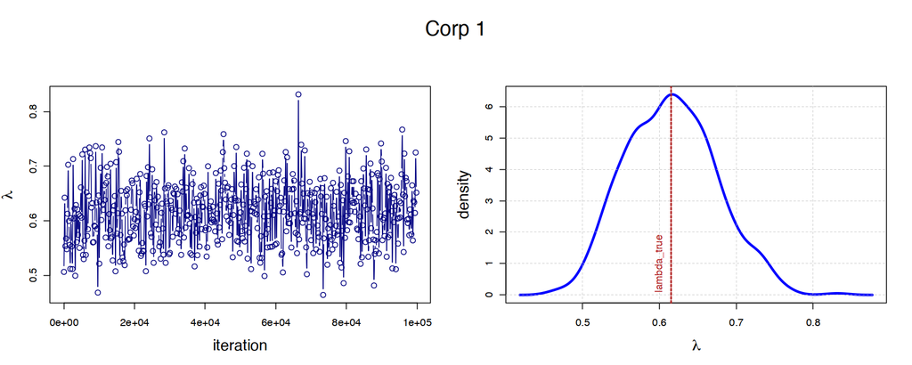

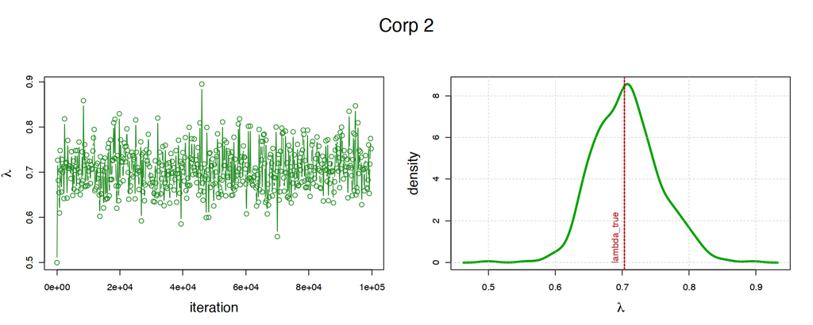

```r
set.seed(300523)
chain1 <- metropolis(unif_post, lambda_init, n_samples, sigma, 1)
chain2 <- metropolis(unif_post, lambda_init, n_samples, sigma, 2)

# plot the evolution of the chain every 200 points
n_steps <- 200

options(repr.plot.width = 15, repr.plot.height = 6)
par(mfrow = c(1,2), oma = c(0, 0, 3, 0))

# corp 1
plot(seq(1, n_samples, n_steps), chain1[seq(1, n_samples, n_steps), 2],
    type = 'b', col = 'navy',
    xlab = 'iteration', ylab = expression(paste(lambda)),
    cex.lab = 1.5)

postden1 <- density(chain1[seq(1, n_samples, n_steps),2], n = 2^10)
plot(postden1$x, postden1$y,
    type = 'l', lwd = 3,
    col = "blue",
    xlab = expression(paste(lambda)), ylab = "density",
    cex.lab = 1.5)
abline(v = mean1$value,
	lty = 2, lwd = 2,
	col = 'firebrick',
    text = text(x = 0.6, y = 1, srt = 90, paste("lambda_true"), col = 'firebrick'))
grid(nx = NULL, ny = NULL,
	lty = 2, lwd = 0.5,
	col = 'gray')
mtext("Corp 1", 3, 0, outer = TRUE, cex = 2)

par(mfrow = c(1,2), oma = c(0, 0, 3, 0))

# corp 2
plot(seq(1, n_samples, n_steps), chain2[seq(1, n_samples, n_steps), 2],
    type = 'b', col = 'forest green',
    xlab = 'iteration', ylab = expression(paste(lambda)),
    cex.lab = 1.5)

postden2 <- density(chain2[seq(1, n_samples, n_steps),2], n = 2^10)
plot(postden2$x, postden2$y,
    type = 'l', lwd = 3,
    col = "#00a200",
    xlab = expression(paste(lambda)), ylab = "density",
    cex.lab = 1.5)
abline(v = mean2$value,
	lty = 2, lwd = 2,
	col = 'firebrick',
    text = text(x = 0.69, y = 1.2, srt = 90, paste("lambda_true"), col = 'firebrick'))
grid(nx = NULL, ny = NULL,
	lty = 2, lwd = 0.5,
	col = 'gray')
mtext("Corp 2", 3, 0, outer = TRUE, cex = 2)
```

```r
# find the lambda that correspond to the maximum of the posterior
lambda1 <- lambda[which.max(postden1$y)]
lambda2 <- lambda[which.max(postden2$y)]

cat(paste("The best estime for lambda in the two cases are:", lambda1, "for the corp 1, and ", lambda2, "for the corp 2"))
```

```
The best estime for lambda in the two cases are: 0.542 for the corp 1, and  0.634 for the corp 2
```

##### Summary table of $\lambda$ estimes

[output not shown]

Repeat the same analisys for the posteriors obtained with the Jeffrey's priors

```
The acceptance rate is:  32.039 %
The acceptance rate is:  29.244 %
```

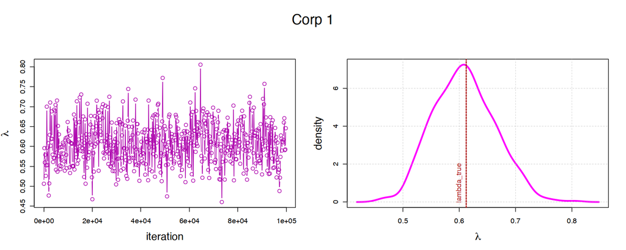

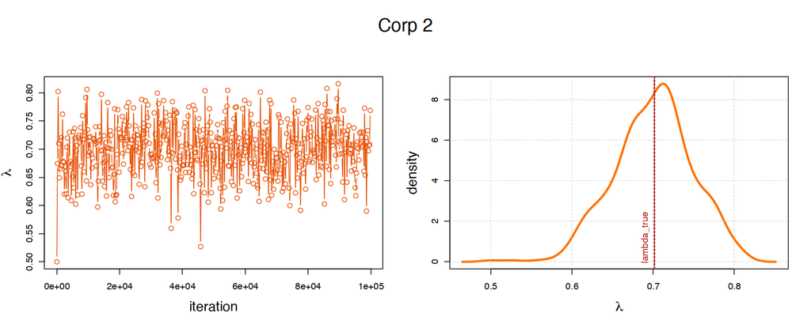

```r
set.seed(300523)
chain1_jeff <- metropolis(jeff_post, lambda_init, n_samples, sigma, 1)
chain2_jeff <- metropolis(jeff_post, lambda_init, n_samples, sigma, 2)

# plot the evolution of the chain every 200 points
n_steps <- 200

options(repr.plot.width = 15, repr.plot.height = 6)
par(mfrow = c(1,2), oma = c(0, 0, 3, 0))

# corp 1
plot(seq(1, n_samples, n_steps), chain1_jeff[seq(1, n_samples, n_steps), 2],
    type = 'b', col = '#ac01ac',
    xlab = 'iteration', ylab = expression(paste(lambda)),
    cex.lab = 1.5)

postden1_jeff <- density(chain1_jeff[seq(1, n_samples, n_steps),2], n = 2^10)
plot(postden1_jeff$x, postden1_jeff$y,
    type = 'l', lwd = 3,
    col = "magenta",
    xlab = expression(paste(lambda)), ylab = "density",
    cex.lab = 1.5)
abline(v = mean1_jeff$value,
	lty = 2, lwd = 2,
	col = 'firebrick',
    text = text(x = 0.6, y = 1, srt = 90, paste("lambda_true"), col = 'firebrick'))
grid(nx = NULL, ny = NULL,
	lty = 2, lwd = 0.5,
	col = 'gray')
mtext("Corp 1", 3, 0, outer = TRUE, cex = 2)

par(mfrow = c(1,2), oma = c(0, 0, 3, 0))

# corp 2
plot(seq(1, n_samples, n_steps), chain2_jeff[seq(1, n_samples, n_steps), 2],
    type = 'b', col = '#e85004',
    xlab = 'iteration', ylab = expression(paste(lambda)),
    cex.lab = 1.5)

postden2_jeff <- density(chain2_jeff[seq(1, n_samples, n_steps),2], n = 2^10)
plot(postden2_jeff$x, postden2_jeff$y,
    type = 'l', lwd = 3,
    col = "#ff7300",
    xlab = expression(paste(lambda)), ylab = "density",
    cex.lab = 1.5)
abline(v = mean2_jeff$value,
	lty = 2, lwd = 2,
	col = 'firebrick',
    text = text(x = 0.69, y = 1.2, srt = 90, paste("lambda_true"), col = 'firebrick'))
grid(nx = NULL, ny = NULL,
	lty = 2, lwd = 0.5,
	col = 'gray')
mtext("Corp 2", 3, 0, outer = TRUE, cex = 2)
```

```r
# find the lambda that correspond to the maximum of the posterior
lambda1_jeff <- lambda[which.max(postden1_jeff$y)]
lambda2_jeff <- lambda[which.max(postden2_jeff$y)]

cat(paste("The best estime for lambda in the two cases are:", lambda1_jeff, "for the corp 1, and ", lambda2_jeff, "for the corp 2"))
```

```
The best estime for lambda in the two cases are: 0.552 for the corp 1, and  0.755 for the corp 2
```

##### Summary table of $\lambda$ estimes

[output not shown]